# HW3-Predictive regression modeling with R

Osarodion

February 8, 2022

## Step 1 - Familiarize yourself with the data and the assignment

This assignment will give you a chance to do a little bit of everything - data wrangling, EDA, and predictive regression modeling. In this assignment you’ll build some predictive regression models with R on a dataset containing used car prices.

The dataset contains a little over 800 used 2005 GM cars. All of these cars were “lightly used” and were less than a year old when put on the used car market.

Most of the fields are self-explanatory. We’ll be trying to predict `Price` using the other variables.

- Price: suggested retail price of the used 2005 GM car in excellent condition. The condition of a car can greatly affect price. All cars in this data set were less than one year old when priced and considered to be in excellent condition.
- Mileage: number of miles the car has been driven
- Make: manufacturer of the car such as Saturn, Pontiac, and Chevrolet
- Model: specific models for each car manufacturer such as Ion, Vibe, Cavalier
- Trim (of car): specific type of car model such as SE Sedan 4D, Quad Coupe 2D
- Type: body type such as sedan, coupe, etc.
- Cylinder: number of cylinders in the engine
- Liter: a more specific measure of engine size
- Doors: number of doors
- Cruise: indicator variable representing whether the car has cruise control (1 = cruise)
- Sound: indicator variable representing whether the car has upgraded speakers (1 = upgraded)
- Leather: indicator variable representing whether the car has leather seats (1 = leather

As we did in HW2, you’ll be creating an R Markdown document to do the analysis as well as to document the steps you did (and answer some questions I’ll throw at you).

You’ll notice a few “Hacker Extra” tasks thrown in. These are for those of you who want to go a little above and beyond and attempt some more challenging tasks.

## Step 2 - Create a new R Markdown document

Save this file as a new R Markdown document and name it something that includes your last name in the filename. Save it into the same folder as this file.

## Step 3 - Create project and load data

Create an R Studio project in the current folder (the one containing this file). You’ll notice that there is a folder named **data**. Inside of it you’ll find the data file for this assignment:

- **car_sales_price.csv**

### Load the data

```r
used_cars <- read.csv("./data/car_sales_price.csv")
```

The assignment will begin with me guiding you through some basic data snooping, cleaning, exploratory data analysis (EDA) and data recoding. Then we’ll move on to regression modeling.

```r
library(dplyr)   # Group by analysis and other SQLish things.
```

```r
library(ggplot2) # Plotting, of course
library(corrplot) # Correlation plots
library(tidyr)   # Data reshaping
library(stringr) # String manipulation
library(caret)   # Many aspects of predictive modeling
library(MLmetrics) # We will use its mae() function for comparing model predictions
library(forcats)   # Useful for dealing with categorical data - this one will be useful. :)
library(skimr)       # An automated EDA tool (you saw this in a previous assignment)
```

Use `str`, `summary`, and `skim` to get a sense of the data. You’ll see there’s a mix of categorical and numeric data. Our response variable, the thing we will be trying to predict is `Price`.

```r
str(used_cars)
```

```
## 'data.frame':    804 obs. of  12 variables:
##  $ Price   : num  17314 17542 16219 16337 16339 ...
##  $ Mileage : int  8221 9135 13196 16342 19832 22236 22576 22964 24021 27325 ...
##  $ Make    : chr  "Buick" "Buick" "Buick" "Buick" ...
##  $ Model   : chr  "Century" "Century" "Century" "Century" ...
##  $ Trim    : chr  "Sedan 4D" "Sedan 4D" "Sedan 4D" "Sedan 4D" ...
##  $ Type    : chr  "Sedan" "Sedan" "Sedan" "Sedan" ...
##  $ Cylinder: int  6 6 6 6 6 6 6 6 6 6 ...
##  $ Liter   : num  3.1 3.1 3.1 3.1 3.1 3.1 3.1 3.1 3.1 3.1 ...
##  $ Doors   : int  4 4 4 4 4 4 4 4 4 4 ...
##  $ Cruise  : chr  "yes" "yes" "yes" "yes" ...
##  $ Sound   : chr  "yes" "yes" "yes" "no" ...
##  $ Leather : chr  "yes" "no" "no" "no" ...
```

```r
summary(used_cars)
```

```
##      Price          Mileage          Make              Model
##  Min.   : 8639   Min.   :  266   Length:804         Length:804
##  1st Qu.:14273   1st Qu.:14624   Class :character   Class :character
##  Median :18025   Median :20914   Mode  :character   Mode  :character
##  Mean   :21343   Mean   :19832
##  3rd Qu.:26717   3rd Qu.:25213
##  Max.   :70755   Max.   :50387
##      Trim               Type              Cylinder         Liter
##  Length:804         Length:804         Min.   :4.000   Min.   :1.600
##  Class :character   Class :character   1st Qu.:4.000   1st Qu.:2.200
##  Mode  :character   Mode  :character   Median :6.000   Median :2.800
##                                        Mean   :5.269   Mean   :3.037
##                                        3rd Qu.:6.000   3rd Qu.:3.800
##                                        Max.   :8.000   Max.   :6.000
##      Doors          Cruise             Sound             Leather
##  Min.   :2.000   Length:804         Length:804         Length:804
##  1st Qu.:4.000   Class :character   Class :character   Class :character
##  Median :4.000   Mode  :character   Mode  :character   Mode  :character
##  Mean   :3.527
##  3rd Qu.:4.000
##  Max.   :4.000
```

```r
skim(used_cars)
```

Data summary

| Name | used_cars |
| --- | --- |
| Number of rows | 804 |
| Number of columns | 12 |
| _______________________ |  |
| Column type frequency: |  |
| character | 7 |
| numeric | 5 |
| ________________________ |  |
| Group variables | None |

**Variable type: character**

| skim_variable | n_missing | complete_rate | min | max | empty | n_unique | whitespace |
| --- | --- | --- | --- | --- | --- | --- | --- |
| Make | 0 | 1 | 4 | 9 | 0 | 6 | 0 |
| Model | 0 | 1 | 2 | 11 | 0 | 32 | 0 |
| Trim | 0 | 1 | 7 | 19 | 0 | 47 | 0 |
| Type | 0 | 1 | 5 | 11 | 0 | 5 | 0 |
| Cruise | 0 | 1 | 2 | 3 | 0 | 2 | 0 |
| Sound | 0 | 1 | 2 | 3 | 0 | 2 | 0 |
| Leather | 0 | 1 | 2 | 3 | 0 | 2 | 0 |

**Variable type: numeric**

| skim_variable | n_missing | complete_rate | mean | sd | p0 | p25 | p50 | p75 | p100 | hist |
| --- | --- | --- | --- | --- | --- | --- | --- | --- | --- | --- |
| Price | 0 | 1 | 21343.14 | 9884.85 | 8638.93 | 14273.07 | 18025.0 | 26717.32 | 70755.47 | ▇▃▁▁▁ |
| Mileage | 0 | 1 | 19831.93 | 8196.32 | 266.00 | 14623.50 | 20913.5 | 25213.00 | 50387.00 | ▂▆▇▁▁ |
| Cylinder | 0 | 1 | 5.27 | 1.39 | 4.00 | 4.00 | 6.0 | 6.00 | 8.00 | ▇▁▆▁▂ |
| Liter | 0 | 1 | 3.04 | 1.11 | 1.60 | 2.20 | 2.8 | 3.80 | 6.00 | ▇▁▆▁▁ |
| Doors | 0 | 1 | 3.53 | 0.85 | 2.00 | 4.00 | 4.0 | 4.00 | 4.00 | ▂▁▁▁▇ |

**QUESTION** Is there any missing data, and if so, which columns?

> There are no missing data

It looks like all of the character variables are good candidates to be factors. Let’s convert them all to factors. You can do this by either directly converting each variable with `as.factor` or you could simply reload the csv file using the appropriate `stringsAsFactors` argument value.

```r
used_cars <- read.csv(file = "./data/car_sales_price.csv", stringsAsFactors = TRUE)
```

```r
str(used_cars)
```

```
## 'data.frame':    804 obs. of  12 variables:
##  $ Price   : num  17314 17542 16219 16337 16339 ...
##  $ Mileage : int  8221 9135 13196 16342 19832 22236 22576 22964 24021 27325 ...
##  $ Make    : Factor w/ 6 levels "Buick","Cadillac",..: 1 1 1 1 1 1 1 1 1 1 ...
##  $ Model   : Factor w/ 32 levels "9_3","9_3 HO",..: 9 9 9 9 9 9 9 9 9 9 ...
##  $ Trim    : Factor w/ 47 levels "Aero Conv 2D",..: 40 40 40 40 40 40 40 40 40 40 ...
##  $ Type    : Factor w/ 5 levels "Convertible",..: 4 4 4 4 4 4 4 4 4 4 ...
##  $ Cylinder: int  6 6 6 6 6 6 6 6 6 6 ...
##  $ Liter   : num  3.1 3.1 3.1 3.1 3.1 3.1 3.1 3.1 3.1 3.1 ...
##  $ Doors   : int  4 4 4 4 4 4 4 4 4 4 ...
##  $ Cruise  : Factor w/ 2 levels "no","yes": 2 2 2 2 2 2 2 2 2 2 ...
##  $ Sound   : Factor w/ 2 levels "no","yes": 2 2 2 1 1 2 2 2 1 2 ...
##  $ Leather : Factor w/ 2 levels "no","yes": 2 1 1 1 2 1 1 1 2 2 ...
```

```r
summary(used_cars)
```

```
##      Price          Mileage             Make          Model
##  Min.   : 8639   Min.   :  266   Buick    : 80   AVEO    : 60
##  1st Qu.:14273   1st Qu.:14624   Cadillac : 80   Cavalier: 60
##  Median :18025   Median :20914   Chevrolet:320   Malibu  : 60
##  Mean   :21343   Mean   :19832   Pontiac  :150   Cobalt  : 50
##  3rd Qu.:26717   3rd Qu.:25213   SAAB     :114   Ion     : 50
##  Max.   :70755   Max.   :50387   Saturn   : 60   9_3 HO  : 40
##                                                  (Other) :484
##             Trim              Type        Cylinder         Liter
##  Sedan 4D     :170   Convertible: 50   Min.   :4.000   Min.   :1.600
##  Coupe 2D     : 50   Coupe      :140   1st Qu.:4.000   1st Qu.:2.200
##  LS Sedan 4D  : 50   Hatchback  : 60   Median :6.000   Median :2.800
##  LS Coupe 2D  : 30   Sedan      :490   Mean   :5.269   Mean   :3.037
##  LT Sedan 4D  : 30   Wagon      : 64   3rd Qu.:6.000   3rd Qu.:3.800
##  Aero Sedan 4D: 20                     Max.   :8.000   Max.   :6.000
##  (Other)      :454
##      Doors       Cruise    Sound     Leather
##  Min.   :2.000   no :199   no :258   no :222
##  1st Qu.:4.000   yes:605   yes:546   yes:582
##  Median :4.000
##  Mean   :3.527
##  3rd Qu.:4.000
##  Max.   :4.000
##
```

```r
skim(used_cars)
```

Data summary

| Name | used_cars |
| --- | --- |
| Number of rows | 804 |
| Number of columns | 12 |
| _______________________ |  |
| Column type frequency: |  |
| factor | 7 |
| numeric | 5 |
| ________________________ |  |
| Group variables | None |

**Variable type: factor**

| skim_variable | n_missing | complete_rate | ordered | n_unique | top_counts |
| --- | --- | --- | --- | --- | --- |
| Make | 0 | 1 | FALSE | 6 | Che: 320, Pon: 150, SAA: 114, Bui: 80 |
| Model | 0 | 1 | FALSE | 32 | AVE: 60, Cav: 60, Mal: 60, Cob: 50 |
| Trim | 0 | 1 | FALSE | 47 | Sed: 170, Cou: 50, LS : 50, LS : 30 |
| Type | 0 | 1 | FALSE | 5 | Sed: 490, Cou: 140, Wag: 64, Hat: 60 |
| Cruise | 0 | 1 | FALSE | 2 | yes: 605, no: 199 |
| Sound | 0 | 1 | FALSE | 2 | yes: 546, no: 258 |
| Leather | 0 | 1 | FALSE | 2 | yes: 582, no: 222 |

**Variable type: numeric**

| skim_variable | n_missing | complete_rate | mean | sd | p0 | p25 | p50 | p75 | p100 | hist |
| --- | --- | --- | --- | --- | --- | --- | --- | --- | --- | --- |
| Price | 0 | 1 | 21343.14 | 9884.85 | 8638.93 | 14273.07 | 18025.0 | 26717.32 | 70755.47 | ▇▃▁▁▁ |
| Mileage | 0 | 1 | 19831.93 | 8196.32 | 266.00 | 14623.50 | 20913.5 | 25213.00 | 50387.00 | ▂▆▇▁▁ |
| Cylinder | 0 | 1 | 5.27 | 1.39 | 4.00 | 4.00 | 6.0 | 6.00 | 8.00 | ▇▁▆▁▂ |
| Liter | 0 | 1 | 3.04 | 1.11 | 1.60 | 2.20 | 2.8 | 3.80 | 6.00 | ▇▁▆▁▁ |
| Doors | 0 | 1 | 3.53 | 0.85 | 2.00 | 4.00 | 4.0 | 4.00 | 4.00 | ▂▁▁▁▇ |

**QUESTION** Look at the factor variables. What challenges do you think the factor variables might pose when we try to use them in multiple linear regression models?

> The factor variables have different levels which create many different categories for the data set

## Step 4 - Partition into training and test sets

We will use the [caret](https://topepo.github.io/caret/) package to do the partitioning of our data into training and test dataframes. Just run this chunk to create training and test datasets. This way we’ll all be working with the same datasets. Notice that the test set is 20% of the full dataset.

```r
# Simple partition into train (80%) and test (20%) set
set.seed(447) # Do NOT change this
trainIndex <- createDataPartition(used_cars$Price, p = .8,
                                  list = FALSE,
                                  times = 1)

ucars_train <- used_cars[as.vector(trainIndex), ]
ucars_test <- used_cars[-as.vector(trainIndex), ]
```

**QUESTION** In our regression notes, we did **NOT** use caret to do the partitioning. Instead we did this:

```
set.seed(447)
testrecs <- sample(nrow(housing), 250)
housing_test <- housing[testrecs,]
housing_fit <- housing[-testrecs,]  # Negative in front of vector means "not in"
```

What advantage does using `createDataPartition` have over this simpler approach?

> createDataPartition can be used to create balanced split of the data. for datasets containing variables as factors, createDataPartition performs random sampling within each class, which should allow for preservation of the overrall class distribution of the data.

## Step 5 - EDA on training data

Now we will start with some EDA on the training dataset `ucars_train`. **The test data will only get used after building models and we want to compare their predictive abilities on data that was NOT used to fit the models.**

As mentioned above, the dependent variable that we are trying to predict is `Price` You’ll notice that `ucars_train` contains a few numeric fields and a few factors (categorical data). You are free to use any of these fields in your regression models to predict `Price`.

We will start by using things like ggplot2 and dplyr to explore the training dataset. You can use other packages as well. Your goal is to gain a general understanding of the variables and perhaps uncover some useful relationships that you can use in your regression models.

Ok, here we go…

### The obvious scatter plot

Anyone who has shopped for used cars knows that the mileage usually affects the price. Create a scatter plot of `Mileage` vs. `Price` (the y-variable).

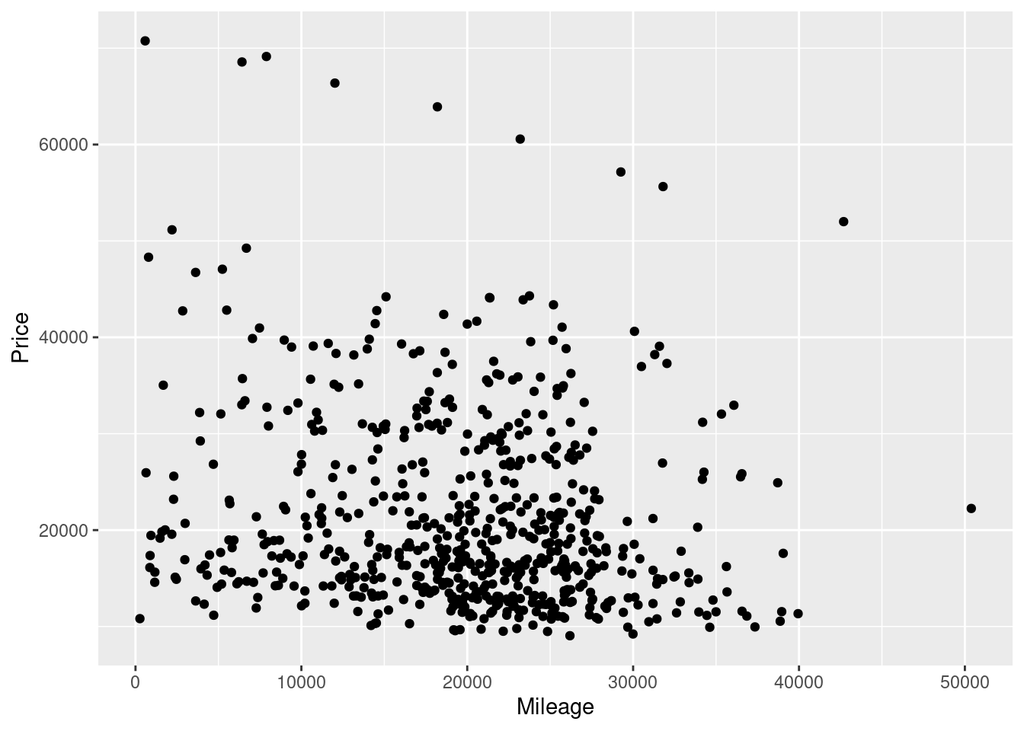

```r
ggplot(ucars_train) +
  geom_point(aes(x=Mileage, y=Price))
```

> The result of the scatter plot appears random but depicts a slightly negative linear association between Price and Mileage

### Correlation analysis

Create a correlation matrix and correlation plot which include all of the numeric variables.

```r
corrmat <- cor(ucars_train[,c(1:2,7:9)])
corrmat
```

```
##               Price     Mileage    Cylinder       Liter       Doors
## Price     1.0000000 -0.15240458  0.56708868  0.55347246 -0.14821995
## Mileage  -0.1524046  1.00000000 -0.02369513 -0.00870257 -0.02530375
## Cylinder  0.5670887 -0.02369513  1.00000000  0.95816778 -0.03496998
## Liter     0.5534725 -0.00870257  0.95816778  1.00000000 -0.11816001
## Doors    -0.1482200 -0.02530375 -0.03496998 -0.11816001  1.00000000
```

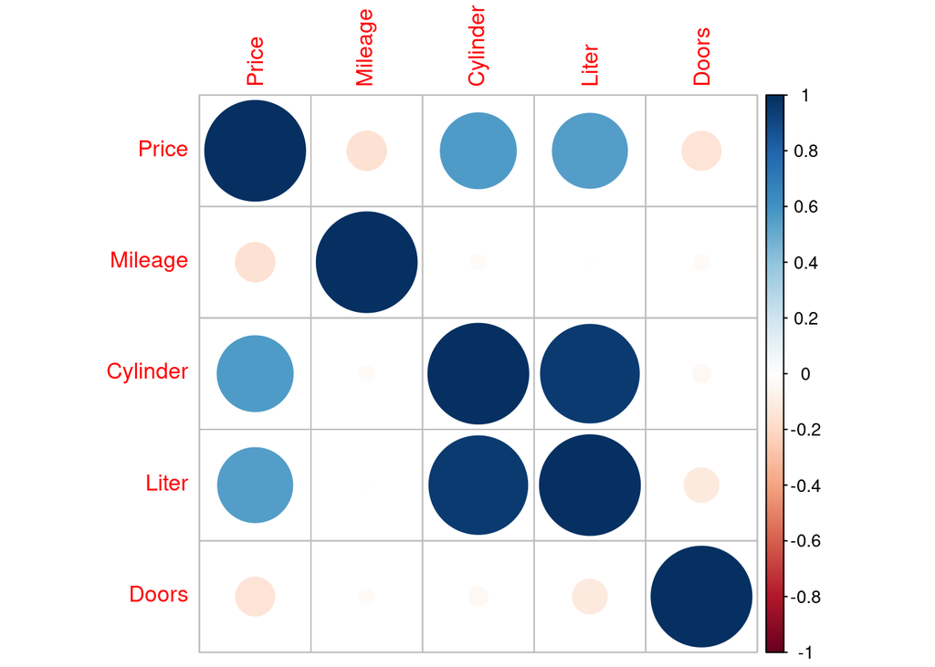

```r
corrplot::corrplot(corrmat, )
```

While this is a common thing to do, you should, in general, **NOT** use it as a screening technique to eliminate variables from future consideration for inclusion in a predictive model.

**QUESTION** Why do you think it could be a bad idea to use correlation analysis to eliminate potential predictor variables? What really is the meaning of a simple correlation coefficient?

> Simple correlation coefficient is a value between -1 and 1 that shows the direction and strength of the relationship between two variables. While correlation analysis can provide a summary of the relationship between variables, it can only determine direct relationship. In regression, we are seeking to determine how much the dependent variable changes given a change in the independent variable. i.e. “y” as a function of “x”

**QUESTION** Are positive correlation values between `Price` and the various predictor variables suggestive of a potentially more predictive variable than a negative correlation value? In other words, would we rather get a correlation value of 0.9 than a value of -0.9?

> No. A negative correlation value could be as predictive as a positive correlation value

### Some dplyr practice

Use dplyr to find the records with the 10 highest `Price` values. Then look back at your scatter plot and comment on these findings.

> The records with the 10 highest ‘Price’ show a negative linear association between ‘Price’ and ‘Mileage’. This is slightly noticeable in the scatter plot, more pronounced in the outliers.

```r
ucars_train_price <- ucars_train %>%
  arrange(desc(Price))

head(ucars_train_price,10)
```

```
##       Price Mileage     Make  Model            Trim        Type Cylinder Liter
## 1  70755.47     583 Cadillac XLR-V8 Hardtop Conv 2D Convertible        8   4.6
## 2  69133.73    7892 Cadillac XLR-V8 Hardtop Conv 2D Convertible        8   4.6
## 3  68566.19    6420 Cadillac XLR-V8 Hardtop Conv 2D Convertible        8   4.6
## 4  66374.31   12021 Cadillac XLR-V8 Hardtop Conv 2D Convertible        8   4.6
## 5  63913.12   18200 Cadillac XLR-V8 Hardtop Conv 2D Convertible        8   4.6
## 6  60567.55   23193 Cadillac XLR-V8 Hardtop Conv 2D Convertible        8   4.6
## 7  57154.44   29260 Cadillac XLR-V8 Hardtop Conv 2D Convertible        8   4.6
## 8  55639.09   31805 Cadillac XLR-V8 Hardtop Conv 2D Convertible        8   4.6
## 9  52001.99   42691 Cadillac XLR-V8 Hardtop Conv 2D Convertible        8   4.6
## 10 51154.05    2202 Cadillac  CST-V        Sedan 4D       Sedan        8   5.7
##    Doors Cruise Sound Leather
## 1      2    yes   yes     yes
## 2      2    yes   yes     yes
## 3      2    yes   yes     yes
## 4      2    yes   yes     yes
## 5      2    yes   yes     yes
## 6      2    yes   yes     yes
## 7      2    yes   yes     yes
## 8      2    yes    no     yes
## 9      2    yes   yes     yes
## 10     4    yes   yes     yes
```

Now let’s use dplyr to do some group by analysis to explore all of the factor variables. I’ve given you a code skeleton to get you started. Obviously you can add more summary stats if you wish. Note, you should also sort the results in descending order by the count.

> Summarize your findings. Does it seem like some of these factors might have value for predicting `Price`? From the group by analysis, The SD for ‘Model’ is relatively low compared to other factors. This is an indication that ‘Model’ might be a good fit. Also, Trim produces a similar result as Model. However, the Sedan 4D and Coupe 2D have a high SD which indicates high variation in prices for these 2 trim types.

```r
# ucars_train %>%
#   group_by(???) %>%
#   summarize(
#     n = n(),
#     mean_price = mean(Price)
#     sd_price = sd(Price)
#   ) %>%
#   arrange(???)
```

```r
ucars_train %>%
  group_by(Make) %>%
  summarize(
    n = n(),
    mean_price = mean(Price),
    sd_price = sd(Price),
    p50 = quantile(Price, 0.5),
    p95 = quantile(Price, 0.95)
  ) %>%
  arrange(desc(n))
```

```
## # A tibble: 6 × 6
##   Make          n mean_price sd_price    p50    p95
##   <fct>     <int>      <dbl>    <dbl>  <dbl>  <dbl>
## 1 Chevrolet   263     16547.    6980. 14642. 36831.
## 2 Pontiac     120     18708.    4286. 17547. 27596.
## 3 SAAB         91     29398.    3519. 29321. 35169.
## 4 Cadillac     63     41101.   10450. 38446. 66128.
## 5 Buick        59     20706.    2882. 21058. 26085.
## 6 Saturn       48     13827.    1752. 13652. 17008.
```

```r
ucars_train %>%
  group_by(Model) %>%
  summarize(
    n = n(),
    mean_price = mean(Price),
    sd_price = sd(Price),
    p50 = quantile(Price, 0.5),
    p95 = quantile(Price, 0.95)
  ) %>%
  arrange(desc(n))
```

```
## # A tibble: 32 × 6
##    Model           n mean_price sd_price    p50    p95
##    <fct>       <int>      <dbl>    <dbl>  <dbl>  <dbl>
##  1 Cavalier       50     12792.    1122. 12682. 14501.
##  2 Malibu         49     17163.    1140. 17090. 19089.
##  3 AVEO           46     10788.     914. 10897. 12385.
##  4 Ion            40     13317.    1274. 13195. 15283.
##  5 Cobalt         39     13961.    1103. 14185. 15684.
##  6 9_3 HO         34     30337.    3993. 30263. 36979.
##  7 Monte Carlo    27     19838.    2103. 20222. 23211.
##  8 Bonneville     26     20904.    2020. 21016. 23546.
##  9 Lacrosse       26     21094.    1526. 21228. 23522.
## 10 Impala         25     19604.    3086. 18913. 25040.
## # … with 22 more rows
```

```r
ucars_train %>%
  group_by(Trim) %>%
  summarize(
    n = n(),
    mean_price = mean(Price),
    sd_price = sd(Price),
    p50 = quantile(Price, 0.5),
    p95 = quantile(Price, 0.95)
  ) %>%
  arrange(desc(n))
```

```
## # A tibble: 47 × 6
##    Trim              n mean_price sd_price    p50    p95
##    <fct>         <int>      <dbl>    <dbl>  <dbl>  <dbl>
##  1 Sedan 4D        144     21820.   10860. 16513. 43815.
##  2 Coupe 2D         44     20756.   10591. 13074. 39325.
##  3 LS Sedan 4D      42     15003.    2834. 14946. 19160.
##  4 LT Sedan 4D      25     14116.    2705. 14509. 17315.
##  5 LS Coupe 2D      24     14908.    2422. 14385. 18894.
##  6 Arc Sedan 4D     19     29632.    2732. 30076. 33368.
##  7 SE Sedan 4D      19     16843.    2337. 16380. 20146.
##  8 Aero Sedan 4D    17     26971.    1586. 27060. 28893.
##  9 GT Sedan 4D      16     18316.    2633. 17627. 22417.
## 10 Quad Coupe 2D    15     14195.    1058. 14078. 15468.
## # … with 37 more rows
```

```r
ucars_train %>%
  group_by(Type) %>%
  summarize(
    n = n(),
    mean_price = mean(Price),
    sd_price = sd(Price),
    p50 = quantile(Price, 0.5),
    p95 = quantile(Price, 0.95)
  ) %>%
  arrange(desc(n))
```

```
## # A tibble: 5 × 6
##   Type            n mean_price sd_price    p50    p95
##   <fct>       <int>      <dbl>    <dbl>  <dbl>  <dbl>
## 1 Sedan         398     20927.    8448. 18650. 38837.
## 2 Coupe         117     17922.    7291. 14771. 34906.
## 3 Wagon          46     23025.    6749. 24587. 31676.
## 4 Hatchback      44     14142.    3595. 13530. 18957.
## 5 Convertible    39     42037.   12485. 36971. 68623.
```

```r
ucars_train %>%
  group_by(Cruise) %>%
  summarize(
    n = n(),
    mean_price = mean(Price),
    sd_price = sd(Price),
    p50 = quantile(Price, 0.5),
    p95 = quantile(Price, 0.95)
  ) %>%
  arrange(desc(n))
```

```
## # A tibble: 2 × 6
##   Cruise     n mean_price sd_price    p50    p95
##   <fct>  <int>      <dbl>    <dbl>  <dbl>  <dbl>
## 1 yes      484     23790.   10279. 21232. 41634.
## 2 no       160     13951.    2389. 13976. 18175.
```

```r
ucars_train %>%
  group_by(Sound) %>%
  summarize(
    n = n(),
    mean_price = mean(Price),
    sd_price = sd(Price),
    p50 = quantile(Price, 0.5),
    p95 = quantile(Price, 0.95)
  ) %>%
  arrange(desc(n))
```

```
## # A tibble: 2 × 6
##   Sound     n mean_price sd_price    p50    p95
##   <fct> <int>      <dbl>    <dbl>  <dbl>  <dbl>
## 1 yes     439     20388.    9903. 17090. 39001.
## 2 no      205     23397.    9742. 21183. 41621.
```

```r
ucars_train %>%
  group_by(Leather) %>%
  summarize(
    n = n(),
    mean_price = mean(Price),
    sd_price = sd(Price),
    p50 = quantile(Price, 0.5),
    p95 = quantile(Price, 0.95)
  ) %>%
  arrange(desc(n))
```

```
## # A tibble: 2 × 6
##   Leather     n mean_price sd_price    p50    p95
##   <fct>   <int>      <dbl>    <dbl>  <dbl>  <dbl>
## 1 yes       466     22239.   10945. 18025. 42201.
## 2 no        178     19008.    6072. 18004. 31969.
```

Let’s do some further exploration of the factor variables using boxplots or violin plots. Create boxplots and violin plots for the `Price` variable using the various factor variables.

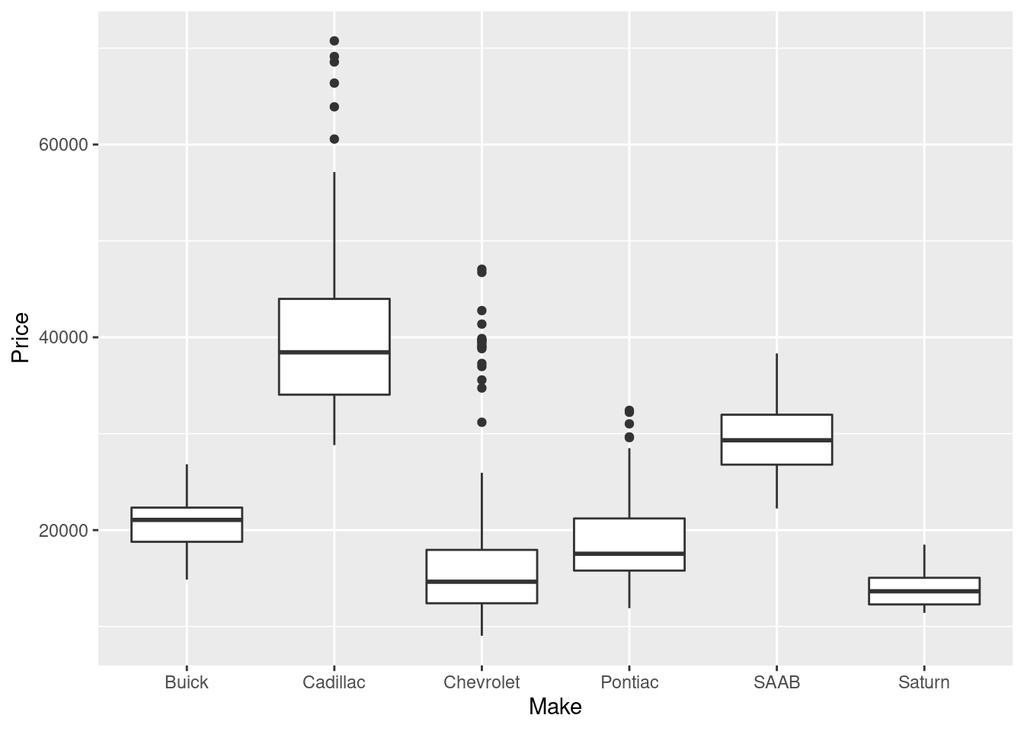

```r
g <- ggplot(ucars_train)

g +
  geom_boxplot(aes(x= Make, y= Price))
```

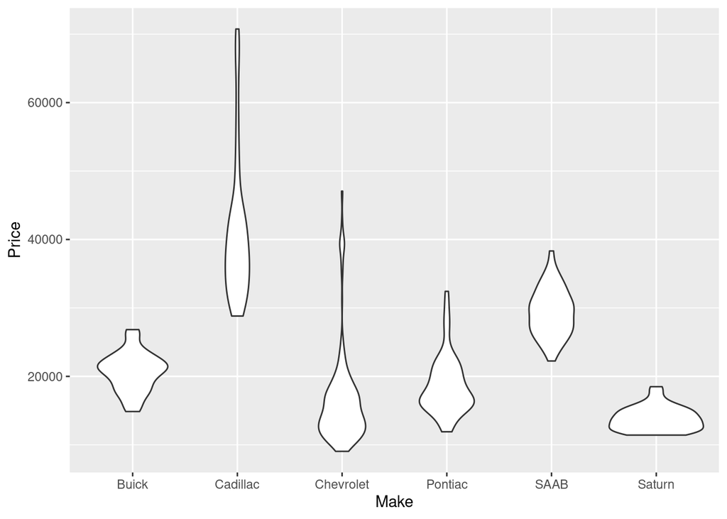

```r
g +
  geom_violin(aes(x= Make, y= Price))
```

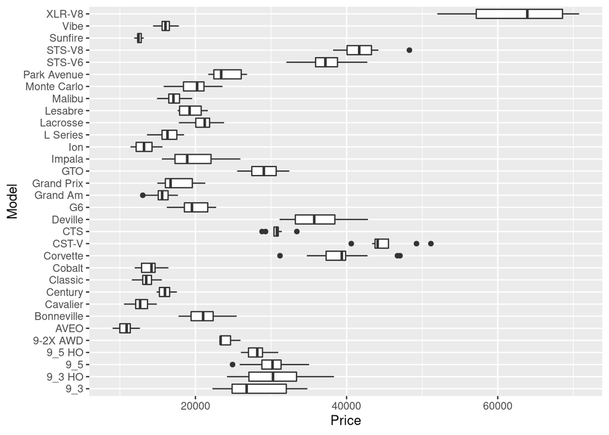

```r
g <- ggplot(ucars_train)

g +
  geom_boxplot(aes(x= Price, y= Model))
```

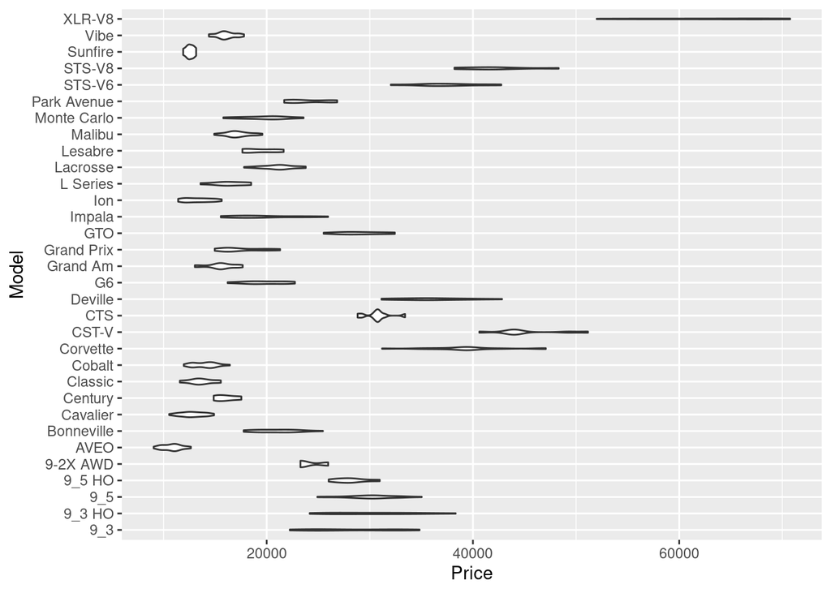

```r
g +
  geom_violin(aes(x= Price, y= Model))
```

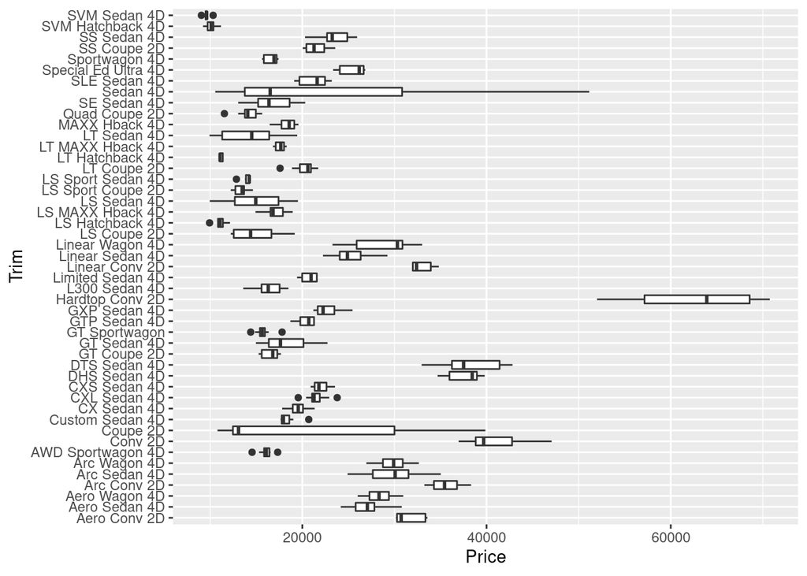

```r
g <- ggplot(ucars_train)

g +
  geom_boxplot(aes(x= Price, y= Trim))
```

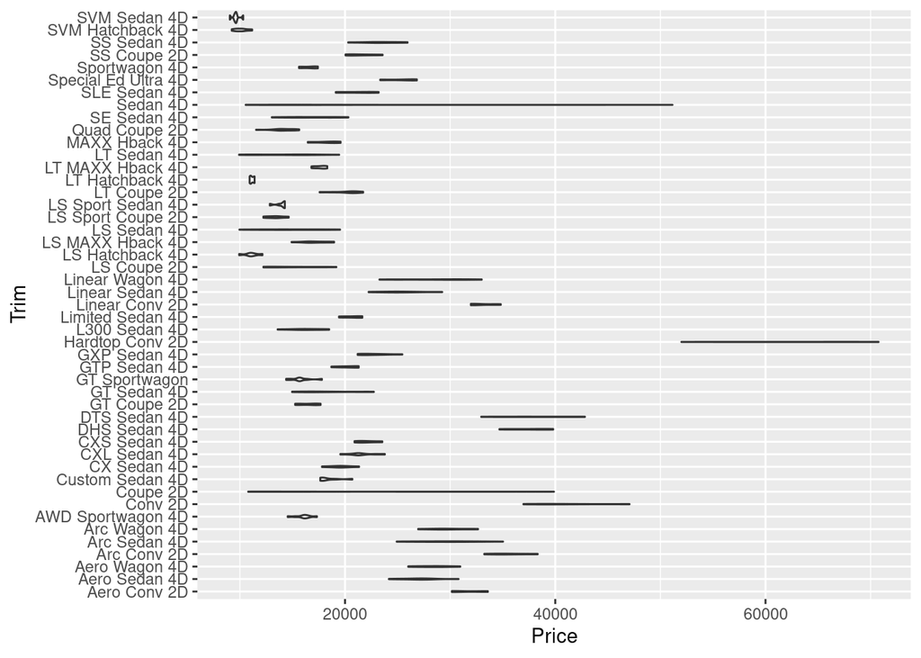

```r
g +
  geom_violin(aes(x= Price, y= Trim))
```

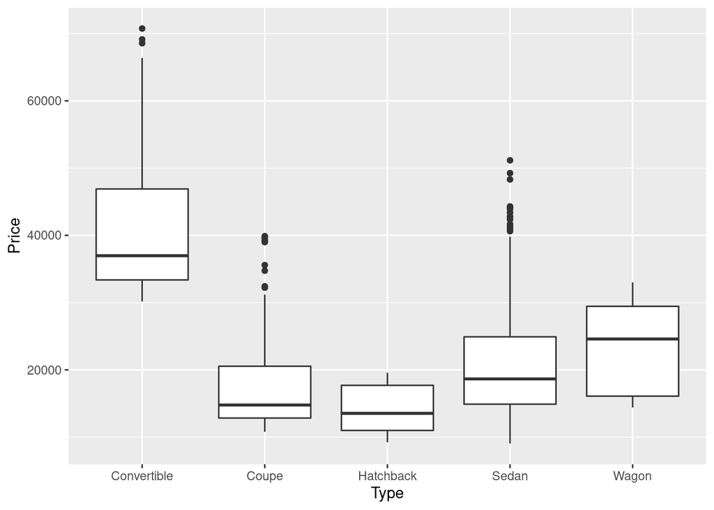

```r
g <- ggplot(ucars_train)

g +
  geom_boxplot(aes(x= Type, y= Price))
```

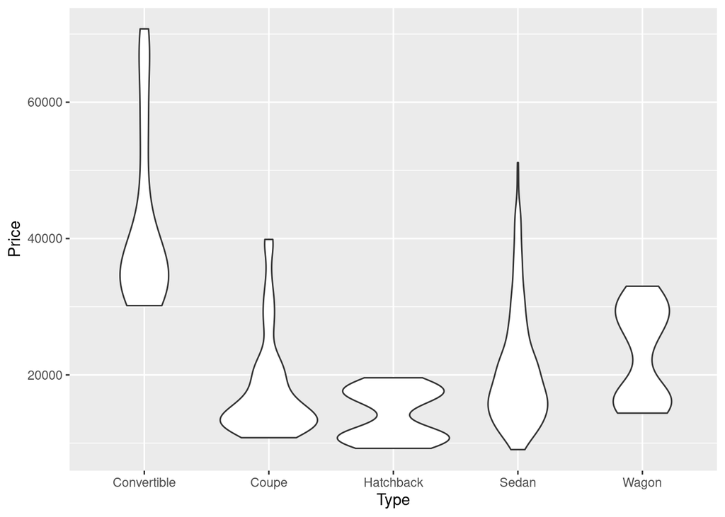

```r
g +
  geom_violin(aes(x= Type, y= Price))
```

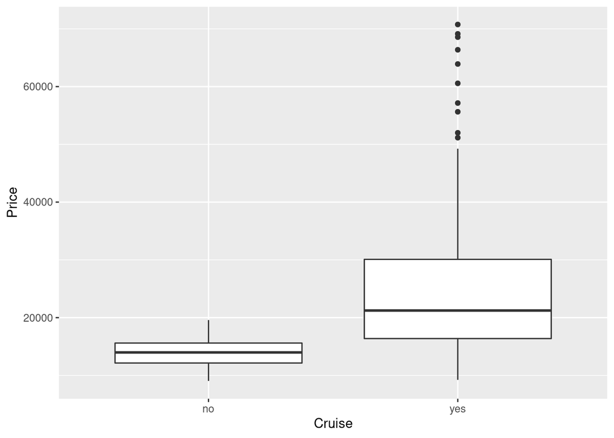

```r
g <- ggplot(ucars_train)

g +
  geom_boxplot(aes(x= Cruise, y= Price))
```

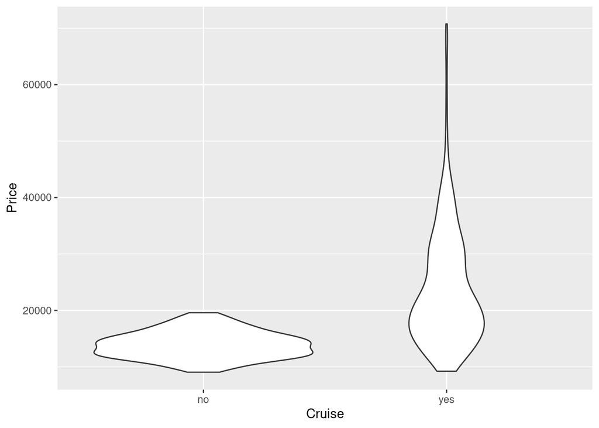

```r
g +
  geom_violin(aes(x= Cruise, y= Price))
```

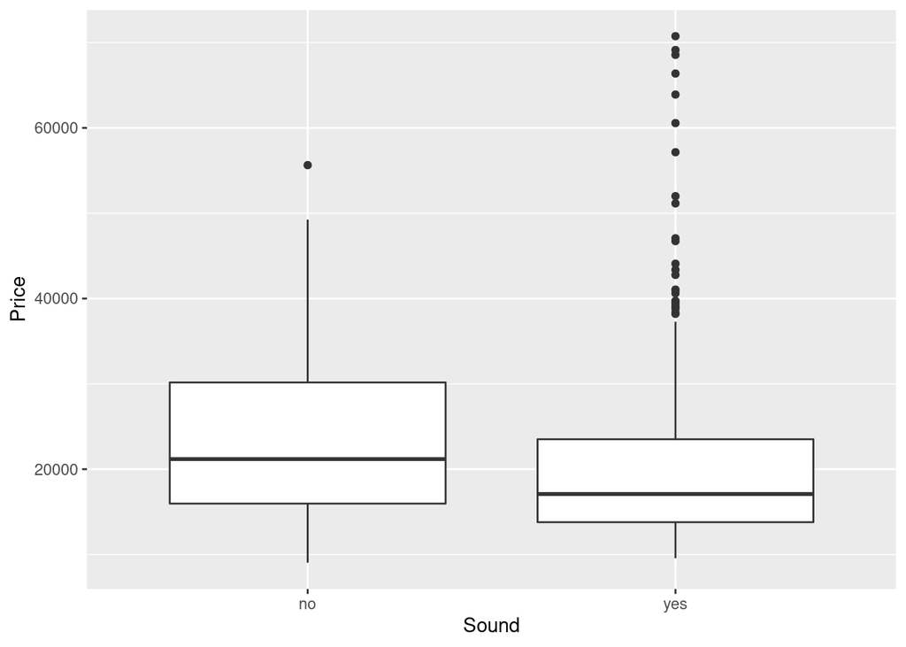

```r
g <- ggplot(ucars_train)

g +
  geom_boxplot(aes(x= Sound, y= Price))
```

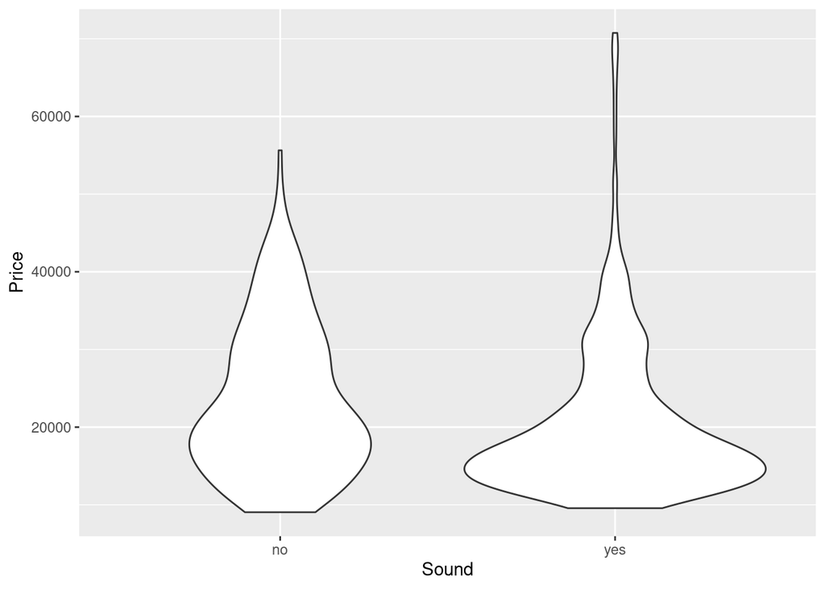

```r
g +
  geom_violin(aes(x= Sound, y= Price))
```

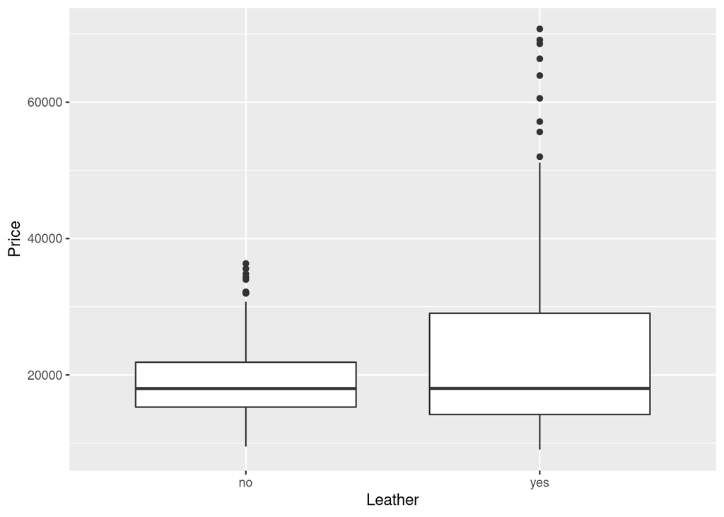

```r
g <- ggplot(ucars_train)

g +
  geom_boxplot(aes(x= Leather, y= Price))
```

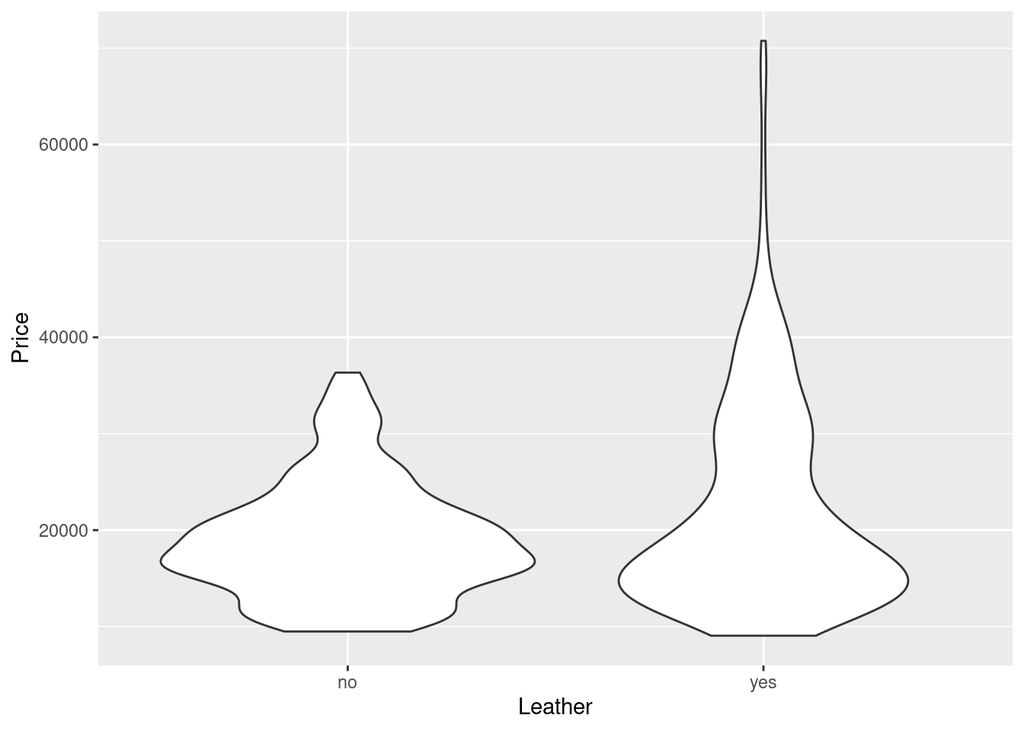

```r
g +
  geom_violin(aes(x= Leather, y= Price))
```

Note any challenges faced when trying this for factors with many levels. For example, if the x-axis labels are overlapping, you should flip the boxplot from vertical to horizontal. Of course, feel free to explore more than just these six variables.

**QUESTION** What do the violin plots reveal that the box plots don’t?

> Unlike the Boxplots, the violin plots show the distribution of the data. For example, the violin plot for ‘Type’ shows the ‘Hatchback’ type as a Bimodal distribution.

## Step 6 - Factor recoding

As alluded to earlier in the assignment, you may run into some issues if you try to use some of the raw factor variables in linear regression. I’ll let you discover these issues on your own if you choose to use some of the raw factor variables in the modeling part below.

One common approach to dealing with factors that have a large number of levels and have very small counts for some of the levels, is to “lump” some of the factor levels into an “other” category. The **forcats** (“for categories”) package has some very useful lumping functions. See https://forcats.tidyverse.org/reference/fct_lump.html.

These can be somewhat tricky to use in that we need to avoid ending up with factor levels in the test data that don’t appear in the training data. If this happens, then we won’t be able to make regression predictions on the test data as the coefficients corresponding to these levels won’t exist. So, it’s probably best to do the factor lumping on the complete, unpartitioned, dataset and then resplit. I’ll demonstrate this with one of the factor lumping functions that let’s us create a new variable in which all levels with n < 10 (or whatever number we choose) are lumped into an “other” category (level). Then I’ll use dplyr to a group by `Model_2` and count the number records in each level of the new field. Notice that the newly create “Other” category is not necessarily the one with the least number of records (there is another forcats function that does do this). Then I’ll show you how to check to make sure that all levels in the lumped variable in the test set also appear in the train set.

I’m going to do this with the `Model` variable. My new, lumped, version will be named `Model_2`.

```r
# Do the factor lumping on original dataset
used_cars$Model_2 <- fct_lump_min(used_cars$Model, min=10)

# Check out the results
used_cars %>%
  group_by(Model_2) %>%
  summarize(
    n = n(),
    mean_charges = mean(Price),
    median_charges = median(Price),
    sd_charges = sd(Price)
  ) %>%
  arrange(desc(n))
```

```
## # A tibble: 32 × 5
##    Model_2        n mean_charges median_charges sd_charges
##    <fct>      <int>        <dbl>          <dbl>      <dbl>
##  1 AVEO          60       10753.         10947.       949.
##  2 Cavalier      60       12866.         12790.      1127.
##  3 Malibu        60       17167.         17042.      1112.
##  4 Cobalt        50       13953.         14048.      1048.
##  5 Ion           50       13464.         13506.      1407.
##  6 9_3 HO        40       30430.         30209.      4141.
##  7 9_5           30       30024.         30297.      2361.
##  8 Bonneville    30       20896.         21016.      1950.
##  9 Deville       30       36238.         35972.      3302.
## 10 Grand Prix    30       17890.         17046.      2115.
## # … with 22 more rows
```

Notice there are only 4 records in Other. This is good. We’ve retained a lot of information and hopefully will not run into the problem of levels showing up in test that weren’t in train.

Now we need to repartition the dataset into train and test.

```r
# Simple partition into train (80%) and test (20%) set
set.seed(447) # Do NOT change this
trainIndex <- createDataPartition(used_cars$Price, p = .8,
                                  list = FALSE,
                                  times = 1)

ucars_train <- used_cars[as.vector(trainIndex), ]
ucars_test <- used_cars[-as.vector(trainIndex), ]
```

As mentioned above, if you are going use any factor variables in your regression models, you need to make sure that there are no levels in the test data that are **NOT** in the training data. If there are, when you try to predict using the test data, R will complain that it’s seeing a new level that was not in the training data (and thus does not have a corresponding coefficient). This SO post is quite helpful - https://stackoverflow.com/questions/12697071/compare-the-levels-of-two-factors. Here’s how we can compare levels of the `Model_2` factor in both the test and train using the `setdiff` function.

```r
# In train but not test (not a problem)
setdiff(levels(ucars_train$Model_2), levels(ucars_test$Model_2))
```

```
## character(0)
```

```r
# In test but not train (this is a problem)
setdiff(levels(ucars_test$Model_2), levels(ucars_train$Model_2))
```

```
## character(0)
```

Perfect. We have zero records in test that are NOT in train.

Feel free to do any factor lumping that you want.

**HACKER EXTRA** What other lumping function in forcats would you use to create an “Other” field in which it had the lowest number of records across all levels? Try out this function on the `Model` field and see how many records end up in the “Other” category. Does it seem useful with this data?

```r
used_cars$Model_2 <- fct_lump_lowfreq(used_cars$Model, other_level = "Other")

# Check out the results
used_cars %>%
  group_by(Model_2) %>%
  summarize(
    n = n(),
    mean_charges = mean(Price),
    median_charges = median(Price),
    sd_charges = sd(Price)
  ) %>%
  arrange(desc(n))
```

```
## # A tibble: 32 × 5
##    Model_2        n mean_charges median_charges sd_charges
##    <fct>      <int>        <dbl>          <dbl>      <dbl>
##  1 AVEO          60       10753.         10947.       949.
##  2 Cavalier      60       12866.         12790.      1127.
##  3 Malibu        60       17167.         17042.      1112.
##  4 Cobalt        50       13953.         14048.      1048.
##  5 Ion           50       13464.         13506.      1407.
##  6 9_3 HO        40       30430.         30209.      4141.
##  7 9_5           30       30024.         30297.      2361.
##  8 Bonneville    30       20896.         21016.      1950.
##  9 Deville       30       36238.         35972.      3302.
## 10 Grand Prix    30       17890.         17046.      2115.
## # … with 22 more rows
```

> fct_lump_lowfreq() can also be used to create an “Other” field with the lowest number of records across all levels. It is useful with this data as ‘R’ determines the levels that are least frequent. It produces the same value of “4” for the “Other” field as using fct_lump_min() with min = 10

## Step 7 - Building and evaluation of predictive models

Now that you know a little more about the data, it’s time to start building a few predictive models for `Price`.

As our error metric for this modeling exercise, we will use MAE (mean absolute error). We will use the built in MAE function from the MLmetrics package.

### Null model

It’s always a good idea to start out with what we call the *null model*. This is the simplest possible model and one that other models better be able to beat. For this regression problem, the null model is simply a regression model that just has a y-intercept. If you remember some of your statistics, you won’t be surprised that the best fit value for the y-intercept in this case is the mean of the response variable, `Price` - `mean(ucars_train$Price)`.

```r
mean(ucars_train$Price)
```

```
## [1] 21345.87
```

```r
price_lm0 <- lm(Price ~ 1, data = ucars_train)
summary(price_lm0)
```

```
##
## Call:
## lm(formula = Price ~ 1, data = ucars_train)
##
## Residuals:
##    Min     1Q Median     3Q    Max
## -12304  -7073  -3321   5371  49410
##
## Coefficients:
##             Estimate Std. Error t value Pr(>|t|)
## (Intercept)  21345.9      391.8   54.48   <2e-16 ***
## ---
## Signif. codes:  0 '***' 0.001 '**' 0.01 '*' 0.05 '.' 0.1 ' ' 1
##
## Residual standard error: 9944 on 643 degrees of freedom
```

In the next chunk, notice how I compute the null prediction as the overall mean in the training data and then compute the MAE based on that null prediction used against both the training and the test data. You’ll see that the mean of `Price` matches the y-intercept in the null regression model above.

```r
# Compute overall mean Price
null_pred <- mean(ucars_train$Price)
sprintf("Null model prediction: %.2f", null_pred)
```

```
## [1] "Null model prediction: 21345.87"
```

```r
# Compute null model MAE on train
null_train_mae <- MAE(ucars_train$Price, null_pred)
sprintf("Null model train MAE: %.2f", null_train_mae)
```

```
## [1] "Null model train MAE: 7618.56"
```

```r
# Compute null model MAE on test
null_test_mae <- MAE(ucars_test$Price, null_pred)
sprintf("Null model test MAE: %.2f", null_test_mae)
```

```
## [1] "Null model test MAE: 7561.78"
```

Soooo, the null model predicts that every car has a price of $21345.87 and our mean error is ~ $7600. Not a great model. :)

We should be able to beat the null model.

**QUESTION** The MAE on test is less than the MAE on train. Is this expected or unexpected and why? > It is expected because the mean price for the test is less than that of the train. The MAE test value is dependent on the magnitude and frequency of the price values in the dataset. Since the partition was unequal and random, the magnitude and frequency of the values in both datasets are unequal. Therefore their MAEs from the mean will differ.

### Your turn to build models

I’ll give you some help building the first model. I’m doing things just like I did in the Rmd files/screencasts from the Modeling 1 session. My basic analysis flow is:

- fit a linear model with `lm` using the training data
- use `summary()` on the model object to check out the regression results
- compute the MAE for the fitted model on the training data
- use the fitted model to make predictions for the test data
- compute the MAE on the test data predictions
- do various diagnostic plots or stats that help us understand the model performance
- rinse and repeat…

### Fit a model

Here’s a simple model that just uses the `Mileage` variable as a predictor. Note that we are using the training data to fit our models. Later we will test the models predictive abilities on the test data.

```r
price_lm1 <- lm(Price ~ Mileage, data = ucars_train)
summary(price_lm1)
```

```
##
## Call:
## lm(formula = Price ~ Mileage, data = ucars_train)
##
## Residuals:
##    Min     1Q Median     3Q    Max
## -14151  -7226  -3476   5424  45850
##
## Coefficients:
##               Estimate Std. Error t value Pr(>|t|)
## (Intercept)  2.501e+04  1.016e+03  24.628  < 2e-16 ***
## Mileage     -1.867e-01  4.778e-02  -3.907 0.000103 ***
## ---
## Signif. codes:  0 '***' 0.001 '**' 0.01 '*' 0.05 '.' 0.1 ' ' 1
##
## Residual standard error: 9835 on 642 degrees of freedom
## Multiple R-squared:  0.02323,    Adjusted R-squared:  0.02171
## F-statistic: 15.27 on 1 and 642 DF,  p-value: 0.0001033
```

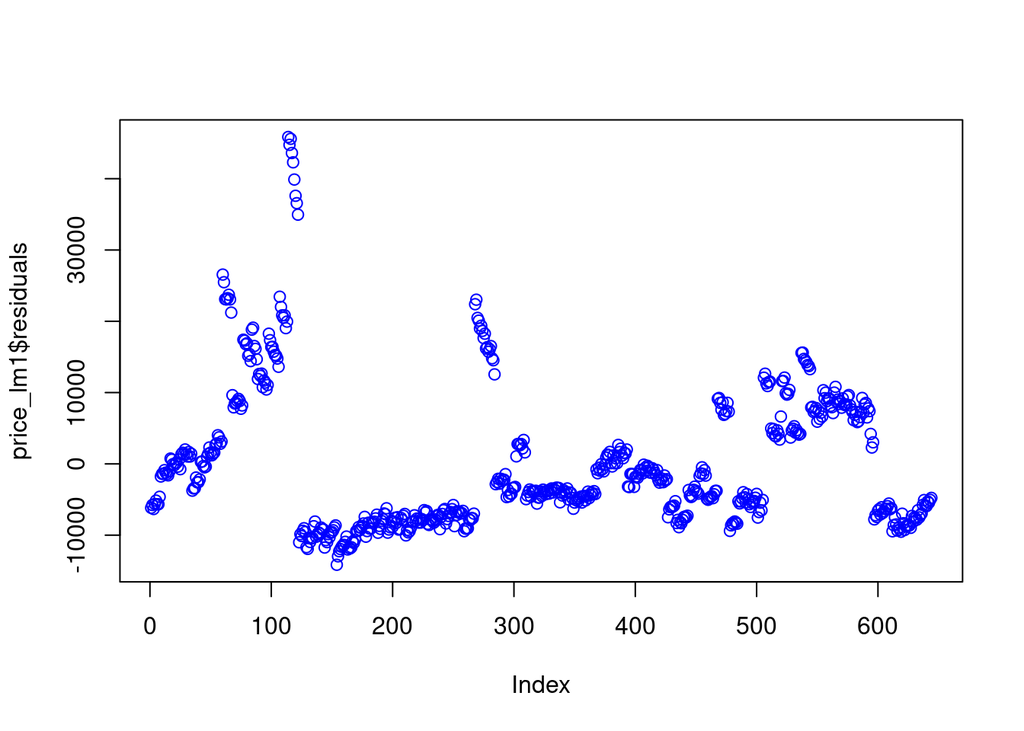

```r
plot(price_lm1$residuals, col = "blue")
```

**QUESTION** How well does `price_lm1` fit and what part of the regression output supports your conclusion? Are the results surprising or not given the scatter plot we looked at earlier? Do you think it’s worth keeping `Mileage` in our model - why or why not?

**QUESTION** Does the sign of the coefficient value make sense to you?

> Yes it does. It indicates a negative linear association. i.e. for every mile added, the price is reduced by 0.1867

### Compute MAE for the fitted model on training data

Now let’s compute the MAE value for `price_lm1` on the training data. As you’ve seen in the class notes, I tend to like to “gather up” my results in vectors so that I can quickly scan performance metrics across models. Right now we just have two models, so I’ll just include those.

```r
mae_train <- c(MAE(ucars_train$Price, price_lm0$fitted.values),
                MAE(ucars_train$Price, price_lm1$fitted.values)
)

mae_train
```

```
## [1] 7618.563 7585.276
```

**QUESTION** Does the MAE comparison between `price_lm0` and `price_lm1` make sense? Why?

> Yes it does. price_lm0 is the null model, which serves as the base model. The MAE for price_lm1 is lower than that of the null model, which makes it a better model than the null model.

### Use fitted model to make predictions on test data

Now let’s make predictions on the test data for `lm1`. See regression notes.

```r
predict_lm1 <- predict(price_lm1, newdata = ucars_test)
# predict_lm1
```

**QUESTION** Is `predict_lm1` a vector, a model object, or a dataframe?

> predict_lm1 is a vector

### Compute MAE for the predictions on the test data

Now we can compute the MAE value for `lm1` on the test data. Again, I’ve included the null model results too.

```r
mae_test <- c(MAE(ucars_test$Price, null_pred),
                MAE(ucars_test$Price, predict_lm1)
)

mae_test
```

```
## [1] 7561.785 7614.857
```

### More Model building

Now, it’s your turn to create the best linear regression model you can based on this dataset. You can do data transformations or recoding but you CANNOT add any new outside data.

For each model, fit it using the training data and then make predictions on the test data. Compute MAE for both the fits and predictions for each of your models (just like I did above)

**QUESTION** Discuss your results. Which model(s) fit the best and which predicted the best? Were the MAE values higher during the fit stage (i.e. when you used training data) or the prediction stage (i.e. when you used your model fitted on train to make predictions for test)? Does this result make sense? Why or why not? If you had to pick one of your models to use going forward, which would it be and why?

> PUT YOUR DISCUSSION TO ABOVE QUESTION IN AN APPROPRIATE SPOT IN YOUR RMD FILE

```r
price_lm2 <- lm(Price ~ Model_2 + Cylinder, data = ucars_train)
price_lm3 <- lm(Price ~ Model_2 + Mileage * Liter, data = ucars_train)
price_lm4 <- lm(Price ~ Model_2 + Doors, data = ucars_train)

summary(price_lm2)
```

```
##
## Call:
## lm(formula = Price ~ Model_2 + Cylinder, data = ucars_train)
##
## Residuals:
##      Min       1Q   Median       3Q      Max
## -10676.4  -1219.1    -74.7   1073.4   8077.0
##
## Coefficients:
##                    Estimate Std. Error t value Pr(>|t|)
## (Intercept)         24053.6     1559.7  15.422  < 2e-16 ***
## Model_29_3 HO        2013.8      697.2   2.889  0.00401 **
## Model_29_5           1833.7      740.3   2.477  0.01352 *
## Model_29_5 HO        -150.3      821.3  -0.183  0.85487
## Model_2AVEO        -17534.9      668.7 -26.221  < 2e-16 ***
## Model_2Bonneville  -10210.2     1194.9  -8.545  < 2e-16 ***
## Model_2Cavalier    -15530.5      662.1 -23.455  < 2e-16 ***
## Model_2Century     -14416.6     1222.1 -11.797  < 2e-16 ***
## Model_2Classic     -14724.9      918.2 -16.036  < 2e-16 ***
## Model_2Cobalt      -14361.8      683.3 -21.017  < 2e-16 ***
## Model_2Corvette      6749.5     1652.4   4.085 5.00e-05 ***
## Model_2CST-V        12508.5     1750.7   7.145 2.58e-12 ***
## Model_2CTS            266.1     1193.0   0.223  0.82358
## Model_2Deville       3405.2     1635.1   2.083  0.03771 *
## Model_2G6          -10625.8     1094.7  -9.707  < 2e-16 ***
## Model_2Grand Am    -13631.8      850.7 -16.025  < 2e-16 ***
## Model_2Grand Prix  -12847.4     1035.3 -12.409  < 2e-16 ***
## Model_2GTO          -3461.8     1714.2  -2.019  0.04388 *
## Model_2Impala      -10853.0     1031.3 -10.524  < 2e-16 ***
## Model_2Ion         -15006.1      681.0 -22.037  < 2e-16 ***
## Model_2L Series    -14079.4     1222.1 -11.521  < 2e-16 ***
## Model_2Lacrosse     -9363.0     1027.5  -9.113  < 2e-16 ***
## Model_2Lesabre     -11076.9     1132.6  -9.780  < 2e-16 ***
## Model_2Malibu      -13294.4      982.0 -13.538  < 2e-16 ***
## Model_2Monte Carlo -10619.4     1024.0 -10.371  < 2e-16 ***
## Model_2Park Avenue  -6433.0     1118.1  -5.753 1.39e-08 ***
## Model_2STS-V6        6999.5     1193.0   5.867 7.27e-09 ***
## Model_2STS-V8        9536.6     1776.4   5.369 1.13e-07 ***
## Model_2Sunfire     -15763.9     1029.5 -15.312  < 2e-16 ***
## Model_2Vibe        -12253.7      760.4 -16.116  < 2e-16 ***
## Model_2XLR-V8       30086.4     1730.6  17.385  < 2e-16 ***
## Model_2Other        -4135.2     1422.5  -2.907  0.00378 **
## Cylinder             1067.3      361.9   2.949  0.00331 **
## ---
## Signif. codes:  0 '***' 0.001 '**' 0.01 '*' 0.05 '.' 0.1 ' ' 1
##
## Residual standard error: 2249 on 611 degrees of freedom
## Multiple R-squared:  0.9514, Adjusted R-squared:  0.9488
## F-statistic: 373.7 on 32 and 611 DF,  p-value: < 2.2e-16
```

```r
summary(price_lm3)
```

```
##
## Call:
## lm(formula = Price ~ Model_2 + Mileage * Liter, data = ucars_train)
##
## Residuals:
##     Min      1Q  Median      3Q     Max
## -5238.5  -787.1     3.0   746.3  7142.6
##
## Coefficients:
##                      Estimate Std. Error t value Pr(>|t|)
## (Intercept)         2.417e+04  1.253e+03  19.297  < 2e-16 ***
## Model_29_3 HO       1.700e+03  5.268e+02   3.227 0.001317 **
## Model_29_5          8.784e+02  5.826e+02   1.508 0.132176
## Model_29_5 HO      -8.564e+02  6.408e+02  -1.337 0.181874
## Model_2AVEO        -1.682e+04  5.496e+02 -30.600  < 2e-16 ***
## Model_2Bonneville  -1.265e+04  1.245e+03 -10.160  < 2e-16 ***
## Model_2Cavalier    -1.624e+04  5.119e+02 -31.716  < 2e-16 ***
## Model_2Century     -1.549e+04  9.565e+02 -16.197  < 2e-16 ***
## Model_2Classic     -1.533e+04  7.014e+02 -21.853  < 2e-16 ***
## Model_2Cobalt      -1.524e+04  5.285e+02 -28.838  < 2e-16 ***
## Model_2Corvette     6.957e+02  2.263e+03   0.307 0.758620
## Model_2CST-V        7.477e+03  2.151e+03   3.477 0.000544 ***
## Model_2CTS         -4.591e+02  8.415e+02  -0.546 0.585525
## Model_2Deville      8.854e+02  1.530e+03   0.579 0.563118
## Model_2G6          -1.256e+04  1.028e+03 -12.220  < 2e-16 ***
## Model_2Grand Am    -1.582e+04  7.185e+02 -22.017  < 2e-16 ***
## Model_2Grand Prix  -1.505e+04  1.130e+03 -13.317  < 2e-16 ***
## Model_2GTO         -7.968e+03  2.135e+03  -3.732 0.000208 ***
## Model_2Impala      -1.284e+04  1.128e+03 -11.382  < 2e-16 ***
## Model_2Ion         -1.547e+04  5.251e+02 -29.454  < 2e-16 ***
## Model_2L Series    -1.500e+04  9.235e+02 -16.238  < 2e-16 ***
## Model_2Lacrosse    -1.112e+04  1.065e+03 -10.447  < 2e-16 ***
## Model_2Lesabre     -1.325e+04  1.182e+03 -11.211  < 2e-16 ***
## Model_2Malibu      -1.515e+04  9.604e+02 -15.771  < 2e-16 ***
## Model_2Monte Carlo -1.296e+04  1.124e+03 -11.529  < 2e-16 ***
## Model_2Park Avenue -9.329e+03  1.175e+03  -7.939 9.82e-15 ***
## Model_2STS-V6       4.780e+03  1.130e+03   4.231 2.68e-05 ***
## Model_2STS-V8       7.491e+03  1.618e+03   4.631 4.46e-06 ***
## Model_2Sunfire     -1.631e+04  7.843e+02 -20.798  < 2e-16 ***
## Model_2Vibe        -1.207e+04  5.843e+02 -20.655  < 2e-16 ***
## Model_2XLR-V8       2.770e+04  1.589e+03  17.430  < 2e-16 ***
## Model_2Other       -5.350e+03  1.107e+03  -4.832 1.72e-06 ***
## Mileage            -2.082e-02  2.365e-02  -0.880 0.378974
## Liter               3.371e+03  5.579e+02   6.042 2.65e-09 ***
## Mileage:Liter      -4.889e-02  7.105e-03  -6.881 1.48e-11 ***
## ---
## Signif. codes:  0 '***' 0.001 '**' 0.01 '*' 0.05 '.' 0.1 ' ' 1
##
## Residual standard error: 1697 on 609 degrees of freedom
## Multiple R-squared:  0.9724, Adjusted R-squared:  0.9709
## F-statistic: 631.8 on 34 and 609 DF,  p-value: < 2.2e-16
```

```r
summary(price_lm4)
```

```
##
## Call:
## lm(formula = Price ~ Model_2 + Doors, data = ucars_train)
##
## Residuals:
##      Min       1Q   Median       3Q      Max
## -10676.4  -1219.6    -78.8   1150.1   8077.0
##
## Coefficients:
##                    Estimate Std. Error t value Pr(>|t|)
## (Intercept)         31290.1      767.7  40.761  < 2e-16 ***
## Model_29_3 HO        1937.5      683.9   2.833 0.004763 **
## Model_29_5           2575.6      737.4   3.493 0.000512 ***
## Model_29_5 HO         591.5      815.7   0.725 0.468600
## Model_2AVEO        -16793.1      668.4 -25.125  < 2e-16 ***
## Model_2Bonneville   -6676.9      726.7  -9.188  < 2e-16 ***
## Model_2Cavalier    -15827.2      651.4 -24.296  < 2e-16 ***
## Model_2Century     -11540.2      974.3 -11.845  < 2e-16 ***
## Model_2Classic     -13983.1      909.7 -15.371  < 2e-16 ***
## Model_2Cobalt      -14333.2      670.2 -21.386  < 2e-16 ***
## Model_2Corvette      9906.0      804.9  12.307  < 2e-16 ***
## Model_2CST-V        17519.5      974.3  17.982  < 2e-16 ***
## Model_2CTS           3142.5      938.9   3.347 0.000868 ***
## Model_2Deville       8416.2      756.7  11.122  < 2e-16 ***
## Model_2G6           -7749.3      815.7  -9.500  < 2e-16 ***
## Model_2Grand Am    -12774.6      781.4 -16.348  < 2e-16 ***
## Model_2Grand Prix   -9971.0      737.4 -13.522  < 2e-16 ***
## Model_2GTO           -305.3      921.0  -0.331 0.740390
## Model_2Impala       -7976.5      731.8 -10.899  < 2e-16 ***
## Model_2Ion         -14959.8      667.9 -22.398  < 2e-16 ***
## Model_2L Series    -11203.0      974.3 -11.499  < 2e-16 ***
## Model_2Lacrosse     -6486.6      726.7  -8.926  < 2e-16 ***
## Model_2Lesabre      -8200.4      864.0  -9.492  < 2e-16 ***
## Model_2Malibu      -10418.0      663.5 -15.701  < 2e-16 ***
## Model_2Monte Carlo  -9597.5      736.1 -13.038  < 2e-16 ***
## Model_2Park Avenue  -3556.6      845.7  -4.205 3.00e-05 ***
## Model_2STS-V6        9875.9      938.9  10.518  < 2e-16 ***
## Model_2STS-V8       14547.6     1017.9  14.292  < 2e-16 ***
## Model_2Sunfire     -16876.7     1028.0 -16.417  < 2e-16 ***
## Model_2Vibe        -11511.9      756.7 -15.212  < 2e-16 ***
## Model_2XLR-V8       33242.9      949.9  34.996  < 2e-16 ***
## Model_2Other        -3393.4     1401.1  -2.422 0.015725 *
## Doors                -927.3      160.8  -5.765 1.29e-08 ***
## ---
## Signif. codes:  0 '***' 0.001 '**' 0.01 '*' 0.05 '.' 0.1 ' ' 1
##
## Residual standard error: 2206 on 611 degrees of freedom
## Multiple R-squared:  0.9532, Adjusted R-squared:  0.9508
## F-statistic: 389.2 on 32 and 611 DF,  p-value: < 2.2e-16
```

```r
rsqrd <- c(summary(price_lm2)$r.squared, summary(price_lm3)$r.squared, summary(price_lm4)$r.squared)

rsqrd
```

```
## [1] 0.9513837 0.9724295 0.9532357
```

```r
anova(price_lm2, price_lm3, price_lm4)
```

```
## Analysis of Variance Table
##
## Model 1: Price ~ Model_2 + Cylinder
## Model 2: Price ~ Model_2 + Mileage * Liter
## Model 3: Price ~ Model_2 + Doors
##   Res.Df        RSS Df   Sum of Sq      F    Pr(>F)
## 1    611 3090854253
## 2    609 1752835792  2  1338018462 232.44 < 2.2e-16 ***
## 3    611 2973108913 -2 -1220273121 211.98 < 2.2e-16 ***
## ---
## Signif. codes:  0 '***' 0.001 '**' 0.01 '*' 0.05 '.' 0.1 ' ' 1
```

```r
AIC(price_lm2, price_lm3, price_lm4)
```

```
##           df      AIC
## price_lm2 34 11802.90
## price_lm3 36 11441.61
## price_lm4 34 11777.89
```

```r
BIC(price_lm2, price_lm3, price_lm4)
```

```
##           df      BIC
## price_lm2 34 11954.80
## price_lm3 36 11602.45
## price_lm4 34 11929.79
```

```r
mae_train <- c(MAE(ucars_train$Price, price_lm0$fitted.values),
                MAE(ucars_train$Price, price_lm1$fitted.values),
               MAE(ucars_train$Price, price_lm2$fitted.values),
               MAE(ucars_train$Price, price_lm3$fitted.values),
               MAE(ucars_train$Price, price_lm4$fitted.values)
)

mae_train
```

```
## [1] 7618.563 7585.276 1567.160 1158.230 1583.369
```

> With the least MAE value, price_lm3 has the least error from the mean price of the train dataset

```r
predict_lm2 <- predict(price_lm2, newdata = ucars_test)
predict_lm3 <- predict(price_lm3, newdata = ucars_test)
predict_lm4 <- predict(price_lm4, newdata = ucars_test)
```

Use as many code chunks as you wish and mix in commentary as you go. For example, describe your motivation for each of the models you build. Remember, write your commentary in markdown and NOT as code comments in chunks (i.e. just mimic the general flow of this document)

```r
mae_test <- c(MAE(ucars_test$Price, null_pred),
                MAE(ucars_test$Price, predict_lm1),
              MAE(ucars_test$Price, predict_lm2),
              MAE(ucars_test$Price, predict_lm3),
              MAE(ucars_test$Price, predict_lm4)
)

mae_test
```

```
## [1] 7561.785 7614.857 1680.428 1254.624 1740.457
```

> From the MAE test on the predicted models, price_lm3 has the least value which ranks it as the best predictor. Note, the MAE values differed for the “train” and “test” data. This is due to variation in the magnitude and frequency of the values in both datasets.

### Model diagnostics

#### Scatterplots of actual vs fitted values

For your top 3 models, create a scatter plot showing actual vs fitted values of `Price`. It’s convention to have the X-axis be the actuals and the Y-axis the fitted values. Remember, it’s often nice to “gather up” your results into a data frame to facilitate plotting. See the notes on comparing competing regression models.

```r
fit_preds <- data.frame(act_price = ucars_test[,"Price"],
                        lm2_price = predict_lm2,
                        lm3_price = predict_lm3,
                        lm4_price = predict_lm4)

head(fit_preds)
```

```
##    act_price lm2_price lm3_price lm4_price
## 5   16339.17  16040.76  15712.89  16040.76
## 7   15230.00  16040.76  15239.87  16040.76
## 12  20538.09  21094.38  22222.91  21094.38
## 20  17968.84  21094.38  18365.25  21094.38
## 21  22358.88  21094.38  23422.78  21094.38
## 33  23016.01  21094.38  22113.21  21094.38
```

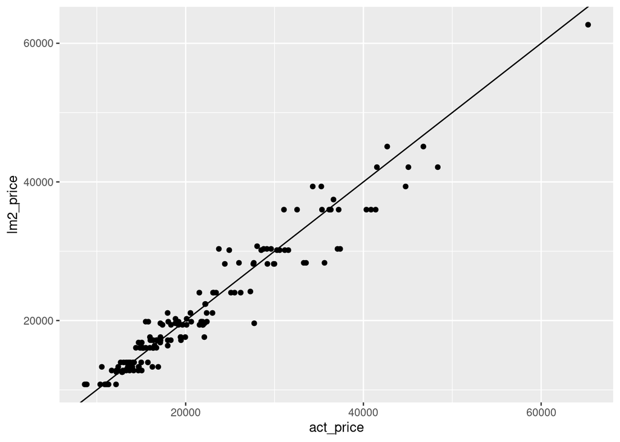

```r
ggplot(fit_preds, aes(x = act_price, y = lm2_price)) + geom_point() + geom_abline()
```

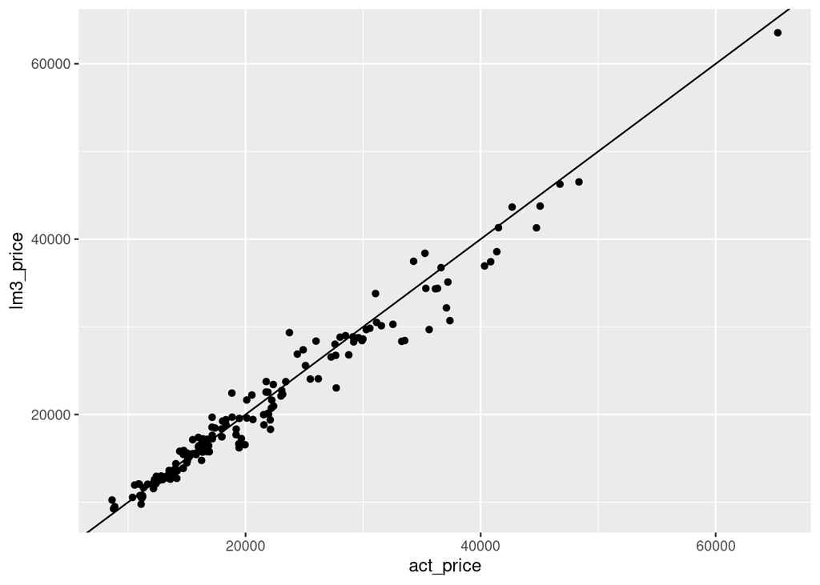

```r
ggplot(fit_preds, aes(x = act_price, y = lm3_price)) + geom_point() + geom_abline()
```

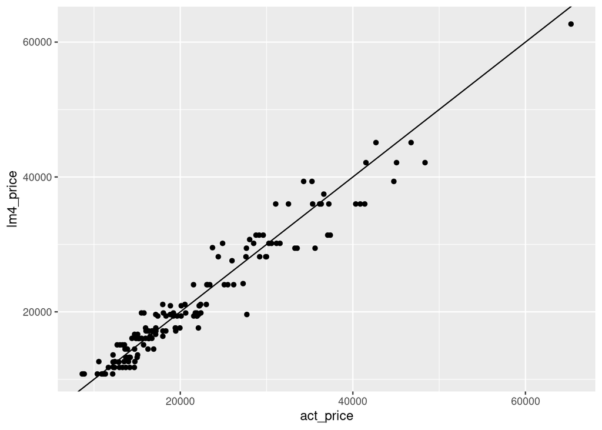

```r
ggplot(fit_preds, aes(x = act_price, y = lm4_price)) + geom_point() + geom_abline()
```

> Based on the scatter plots, the 3rd linear model (price_lm3) fits the best. The abline added to the plots provides a reference to measure the performance of each model. From these results, price_lm3 will be my choice going forward.

#### Constant variance

Make an appropriate plot to check for constant variance (homeskedasticity) for your top model. Don’t remember what kind of plot to make? See my notes on residual analysis or any intro stats book.

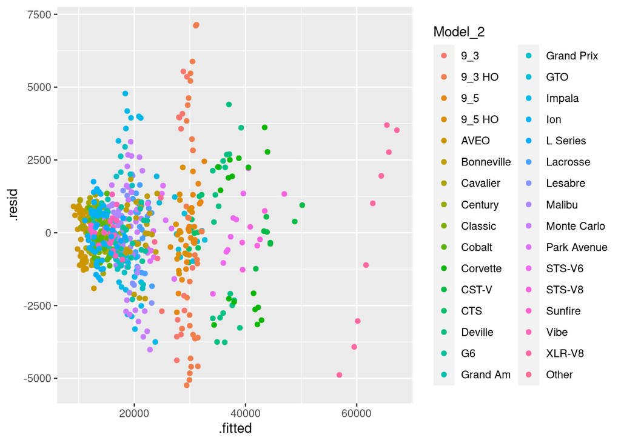

```r
ggplot(data = price_lm3, aes(x = .fitted, y = .resid)) +
  geom_point(aes(color=Model_2))
```

> We do not have constant error variance. The errors are higher at higher price values .i.e. heteroskedastic.

### Your top model

Show your top performing model and discuss whether the model appears to make sense in terms of the variables included. Why did you choose the variables you did?

```r
price_lm3
```

[output not shown]

> In terms of variables included, the linear model (price_lm3) depicts that the price of a car can be predicted from the model, mileage and engine size. The EDA (groupby analysis of the various factors) and the results from combining different variables in fitting the data aided my choice of these variables.

It will be interesting to compare the best models that everyone finds.

Later we’ll learn more techniques that will likely allow us to beat simple linear models.

**HACKER EXTRA 2** We did a simple 80/20 train/test split. Instead, use k-fold cross validation with your training data to compare your models. What is the advantage of this over a simple split? Does it lead to a different ranking of your models?

```r
library(boot)
price_G2 <- glm(Price ~ Model_2 + Cylinder, data = ucars_train)
price_G3 <- glm(Price ~ Model_2 + Mileage * Liter, data = ucars_train)
price_G4 <- glm(Price ~ Model_2 + Doors, data = ucars_train)
```

```r
priceCV2 <- cv.glm(ucars_train, price_G2, K=5)
priceCV3 <- cv.glm(ucars_train, price_G3, K=5)
priceCV4 <- cv.glm(ucars_train, price_G4, K=5)
```

```r
cvResults <- as.data.frame(rbind(priceCV2$delta,
                                 priceCV3$delta,
                                 priceCV4$delta))

#Column names
names(cvResults) <- c("MSE", "MSE.Adjusted")

#Add models to cvResults
cvResults$Model <- sprintf("price_G%s", 2:4)
cvResults
```

```
##       MSE MSE.Adjusted    Model
## 1 5535786      5449984 price_G2
## 2 3034546      2998698 price_G3
## 3 5631107      5509258 price_G4
```

> The k-fold cross validation does not lead to a different ranking of my models. However, it is more efficient than the train/test split as every partition is used for training and testing